# Collate all results

## 3.4 Hazard ratio for age

Hazard ratio is assessed at the mean of all other continuous variables, and the reference value for all categorical variables. the hazard ratio is relative to someone age 40.

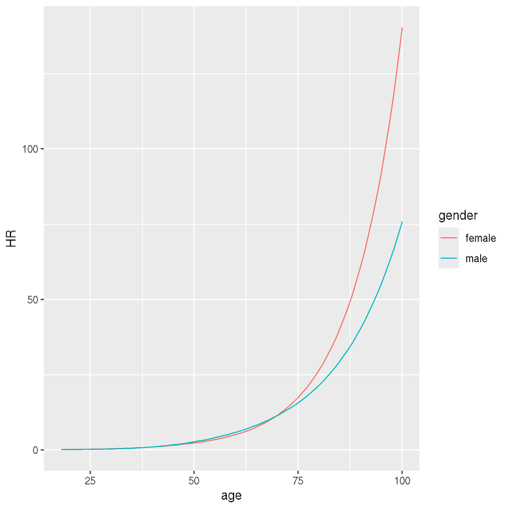

# 4 Model evaluation at baseline (visit 0)

## 4.1 Calibration plots

### 4.1.1 Calibration in the entire cohort

Female:

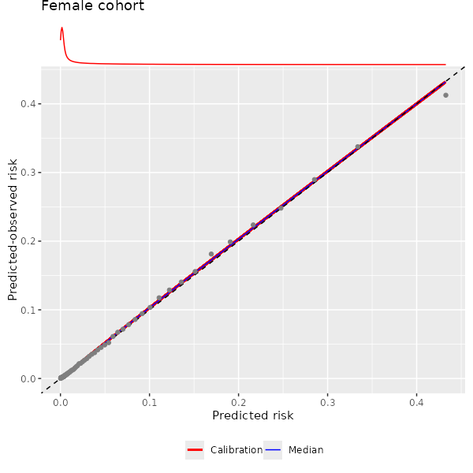

Male:

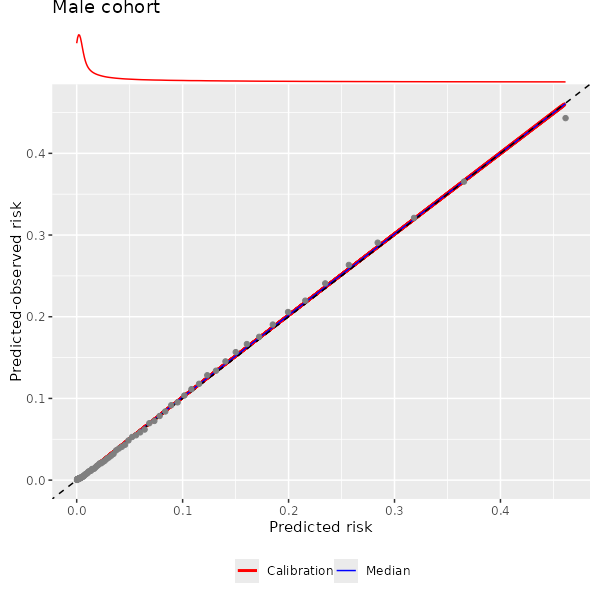

### 4.1.2 Calibration by age

Female:

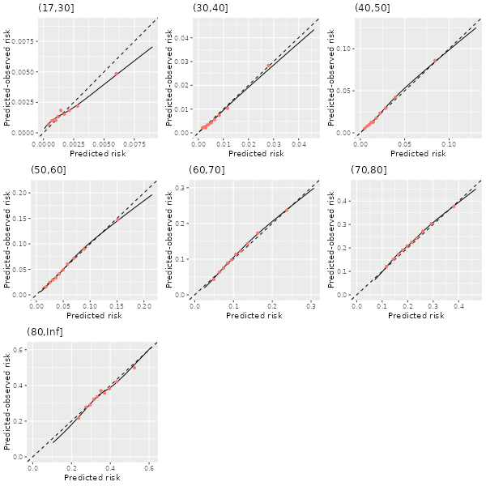

Male:

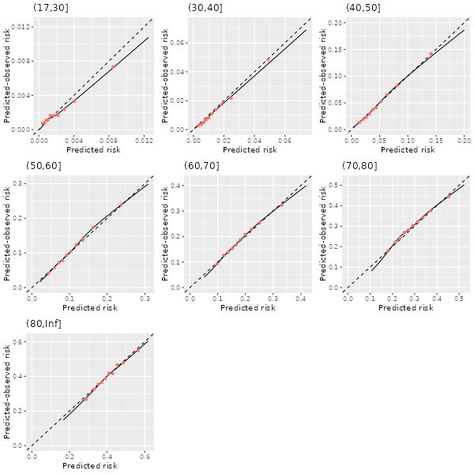

### 4.1.3 Calibration by ethnicity

Female:

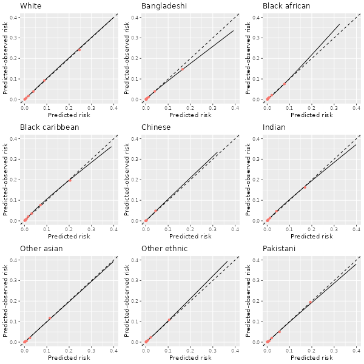

Male:

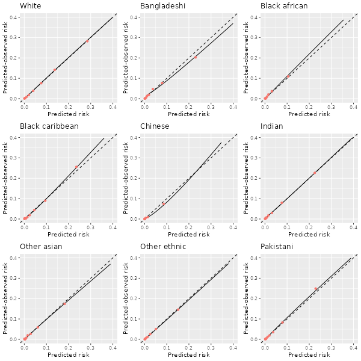

### 4.1.4 Calibration by region

Female:

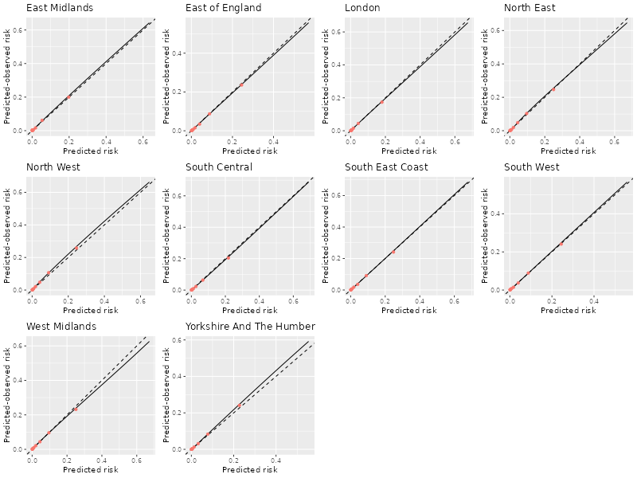

Male:

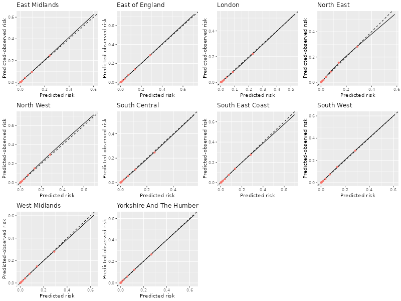

## 4.2 Calibration tables

Female:

|  | N | ICI | E50 | E90 |
| --- | --- | --- | --- | --- |
| Entire cohort | 2969869 | 0.001 | 0.000 | 0.003 |
| White | 2383595 | 0.001 | 0.000 | 0.003 |
| Bangladeshi | 20838 | 0.003 | 0.001 | 0.005 |
| Black african | 89036 | 0.001 | 0.001 | 0.002 |
| Black caribbean | 41817 | 0.002 | 0.001 | 0.006 |
| Chinese | 56055 | 0.000 | 0.000 | 0.001 |
| Indian | 89690 | 0.001 | 0.000 | 0.004 |
| Other asian | 74230 | 0.001 | 0.001 | 0.001 |
| Other ethnic | 166417 | 0.001 | 0.000 | 0.000 |
| Pakistani | 48191 | 0.001 | 0.001 | 0.002 |
| (17,30] | 1212938 | 0.000 | 0.000 | 0.001 |
| (30,40] | 636504 | 0.001 | 0.000 | 0.001 |
| (40,50] | 406103 | 0.001 | 0.000 | 0.003 |
| (50,60] | 305530 | 0.002 | 0.001 | 0.003 |
| (60,70] | 213948 | 0.005 | 0.004 | 0.008 |
| (70,80] | 137794 | 0.009 | 0.009 | 0.011 |
| (80,Inf] | 57052 | 0.007 | 0.005 | 0.015 |
| East Midlands | 84623 | 0.001 | 0.000 | 0.006 |
| East of England | 121992 | 0.001 | 0.001 | 0.003 |
| London | 708877 | 0.001 | 0.000 | 0.001 |
| North East | 83788 | 0.002 | 0.001 | 0.007 |
| North West | 485399 | 0.005 | 0.001 | 0.017 |
| South Central | 352873 | 0.002 | 0.001 | 0.005 |
| South East Coast | 244682 | 0.001 | 0.000 | 0.001 |
| South West | 344630 | 0.001 | 0.000 | 0.002 |
| West Midlands | 428709 | 0.002 | 0.001 | 0.003 |
| Yorkshire And The Humber | 111098 | 0.003 | 0.000 | 0.010 |

Male:

[output not shown]

## 4.3 Discrimination

### 4.3.1 Entire cohort

The mean (sd) and median (2.5th - 97.5th percentile range) across the results when validated in each development/validation pair.

Female:

| mean (sd) | median (p2.5, p97.5) | min | max |
| --- | --- | --- | --- |
| 0.87 (0) | 0.87 (0.87,0.87) | 0.87 | 0.87 |

Male:

| mean (sd) | median (p2.5, p97.5) | min | max |
| --- | --- | --- | --- |
| 0.86 (0) | 0.86 (0.86,0.86) | 0.86 | 0.86 |

### 4.3.2 Across subgroups

Evaluated in one development/validation pair.

Female:

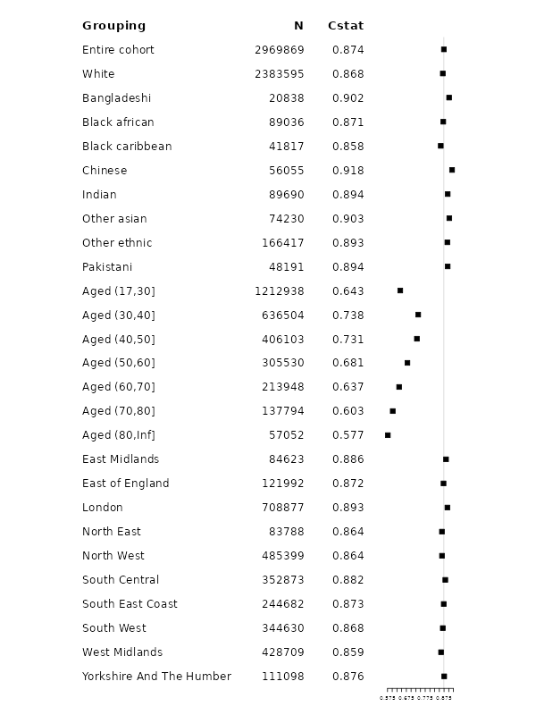

|  | N | C_index | index_lower | index_upper |
| --- | --- | --- | --- | --- |
| Entire cohort | 2969869 | 0.874 | 1.08795e+11 | 1.244425e+11 |
| white | 2383595 | 0.868 | 8.68000e-01 | 8.680000e-01 |
| bangladeshi | 20838 | 0.902 | 9.01000e-01 | 9.020000e-01 |
| black african | 89036 | 0.871 | 8.71000e-01 | 8.710000e-01 |
| black caribbean | 41817 | 0.858 | 8.57000e-01 | 8.580000e-01 |
| chinese | 56055 | 0.918 | 9.17000e-01 | 9.180000e-01 |
| indian | 89690 | 0.894 | 8.94000e-01 | 8.950000e-01 |
| other asian | 74230 | 0.903 | 9.03000e-01 | 9.030000e-01 |
| other ethnic | 166417 | 0.893 | 8.93000e-01 | 8.930000e-01 |
| pakistani | 48191 | 0.894 | 8.94000e-01 | 8.940000e-01 |
| (17,30] | 1212938 | 0.643 | 6.43000e-01 | 6.430000e-01 |
| (30,40] | 636504 | 0.738 | 7.38000e-01 | 7.380000e-01 |
| (40,50] | 406103 | 0.731 | 7.31000e-01 | 7.310000e-01 |
| (50,60] | 305530 | 0.681 | 6.81000e-01 | 6.810000e-01 |
| (60,70] | 213948 | 0.637 | 6.37000e-01 | 6.370000e-01 |
| (70,80] | 137794 | 0.603 | 6.03000e-01 | 6.030000e-01 |
| (80,Inf] | 57052 | 0.577 | 5.77000e-01 | 5.770000e-01 |
| East Midlands | 84623 | 0.886 | 8.85000e-01 | 8.860000e-01 |
| East of England | 121992 | 0.872 | 8.72000e-01 | 8.720000e-01 |
| London | 708877 | 0.893 | 8.93000e-01 | 8.930000e-01 |
| North East | 83788 | 0.864 | 8.64000e-01 | 8.640000e-01 |
| North West | 485399 | 0.864 | 8.64000e-01 | 8.640000e-01 |
| South Central | 352873 | 0.882 | 8.82000e-01 | 8.820000e-01 |
| South East Coast | 244682 | 0.873 | 8.73000e-01 | 8.730000e-01 |
| South West | 344630 | 0.868 | 8.68000e-01 | 8.680000e-01 |
| West Midlands | 428709 | 0.859 | 8.59000e-01 | 8.590000e-01 |
| Yorkshire And The Humber | 111098 | 0.876 | 8.76000e-01 | 8.760000e-01 |

Male:

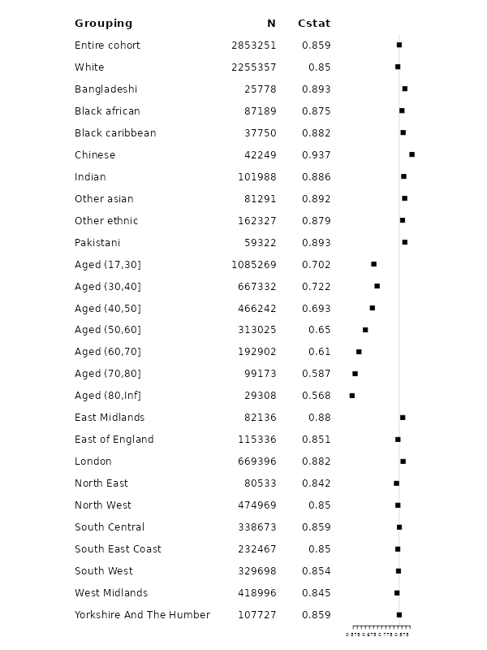

|  | N | C_index | index_lower | index_upper |
| --- | --- | --- | --- | --- |
| Entire cohort | 2853251 | 0.859 | 1.39642e+11 | 1.6261e+11 |
| white | 2255357 | 0.850 | 8.50000e-01 | 8.5000e-01 |
| bangladeshi | 25778 | 0.893 | 8.93000e-01 | 8.9300e-01 |
| black african | 87189 | 0.875 | 8.75000e-01 | 8.7600e-01 |
| black caribbean | 37750 | 0.882 | 8.82000e-01 | 8.8200e-01 |
| chinese | 42249 | 0.937 | 9.37000e-01 | 9.3700e-01 |
| indian | 101988 | 0.886 | 8.86000e-01 | 8.8600e-01 |
| other asian | 81291 | 0.892 | 8.92000e-01 | 8.9200e-01 |
| other ethnic | 162327 | 0.879 | 8.79000e-01 | 8.7900e-01 |
| pakistani | 59322 | 0.893 | 8.93000e-01 | 8.9300e-01 |
| (17,30] | 1085269 | 0.702 | 7.02000e-01 | 7.0200e-01 |
| (30,40] | 667332 | 0.722 | 7.22000e-01 | 7.2200e-01 |
| (40,50] | 466242 | 0.693 | 6.93000e-01 | 6.9300e-01 |
| (50,60] | 313025 | 0.650 | 6.50000e-01 | 6.5000e-01 |
| (60,70] | 192902 | 0.610 | 6.10000e-01 | 6.1100e-01 |
| (70,80] | 99173 | 0.587 | 5.87000e-01 | 5.8700e-01 |
| (80,Inf] | 29308 | 0.568 | 5.68000e-01 | 5.6800e-01 |
| East Midlands | 82136 | 0.880 | 8.80000e-01 | 8.8000e-01 |
| East of England | 115336 | 0.851 | 8.51000e-01 | 8.5100e-01 |
| London | 669396 | 0.882 | 8.82000e-01 | 8.8200e-01 |
| North East | 80533 | 0.842 | 8.42000e-01 | 8.4200e-01 |
| North West | 474969 | 0.850 | 8.50000e-01 | 8.5000e-01 |
| South Central | 338673 | 0.859 | 8.59000e-01 | 8.5900e-01 |
| South East Coast | 232467 | 0.850 | 8.50000e-01 | 8.5000e-01 |
| South West | 329698 | 0.854 | 8.54000e-01 | 8.5400e-01 |
| West Midlands | 418996 | 0.845 | 8.45000e-01 | 8.4500e-01 |
| Yorkshire And The Humber | 107727 | 0.859 | 8.58000e-01 | 8.5900e-01 |

## 4.4 Instability plots

These instability pare plotted for 3,000 randomly selected individuals. The variation on the y-axis represents the expected variability in risk if the development cohort was to be re-sampled from the entire population which it represents, and a model was developed in these re-sampled cohorts. Naturally, variation increases as the predicted risk increases. We see a small number of individuals where the variability exceeds that of other individuals at their level of predicted risk. Looking at these individuals highlights them to be those with a higher number of risk factors.

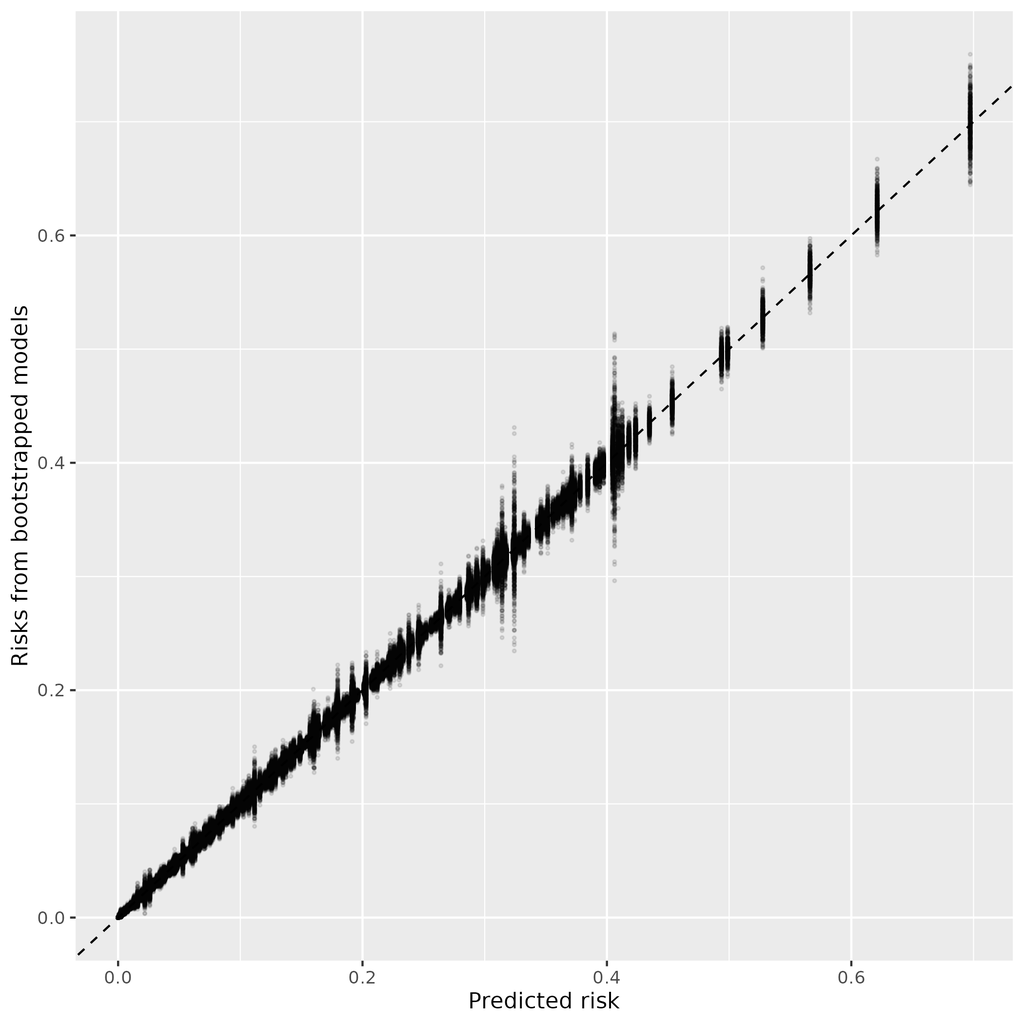

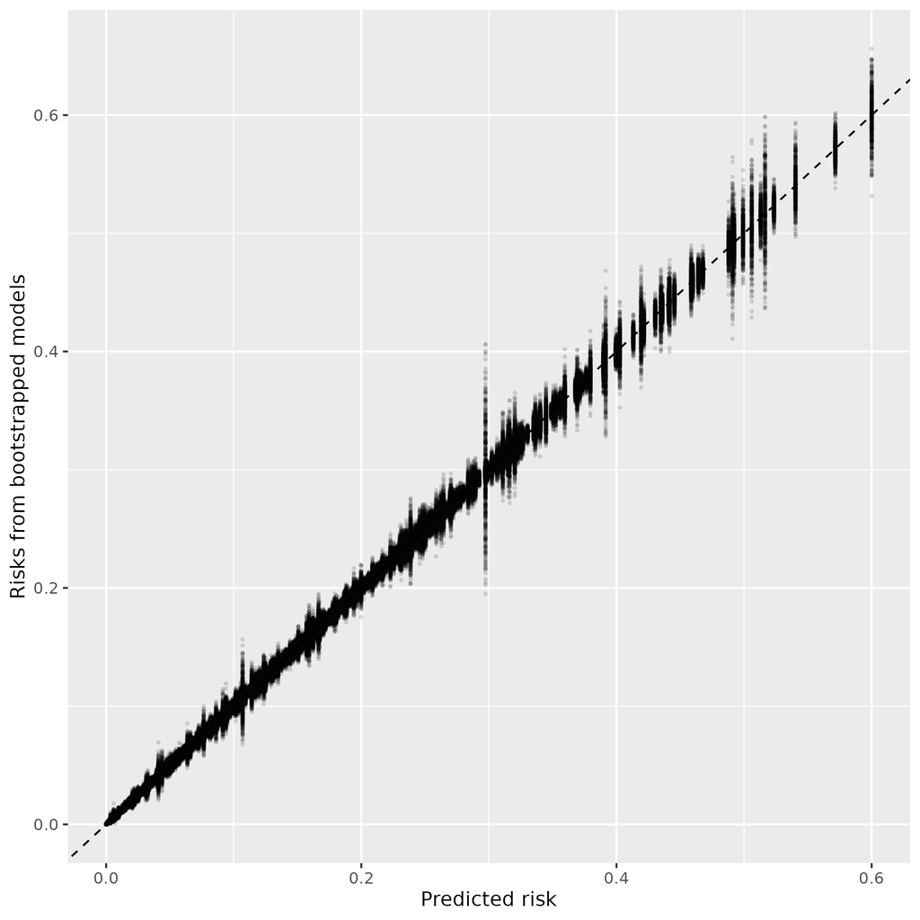

# 5 Temporal validation of initial risk estimation layer

Follow-up index dates are defined at 1/2/3/4/5 years after baseline. Calibration and discrimination are assessed at 5 and 10 years.

In plots and tables, t_fup = number of days after baseline the index date is defined at, t_eval is denoting whether evaluating 5 or 10 year risk predictions.

## 5.1 Calibration plots

### 5.1.1 Female

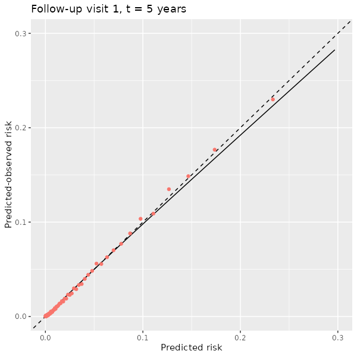

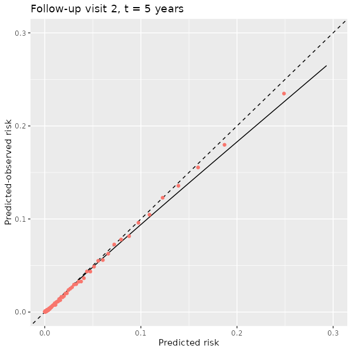

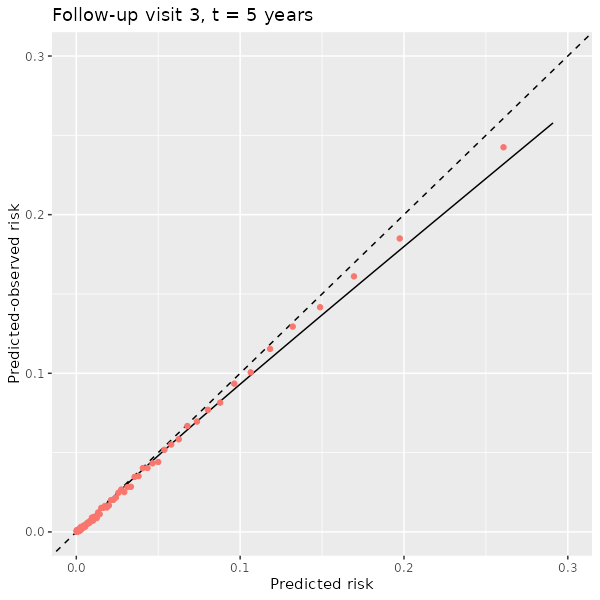

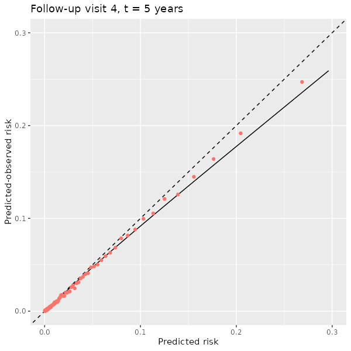

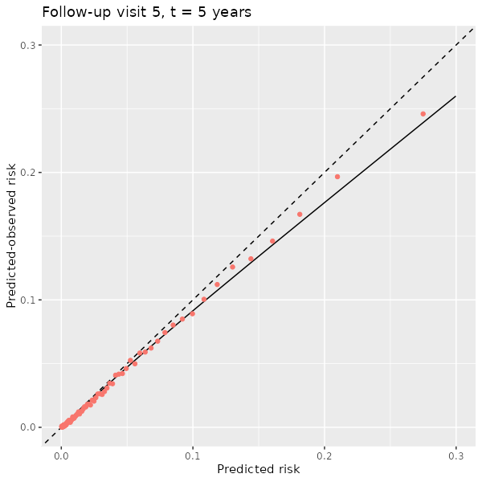

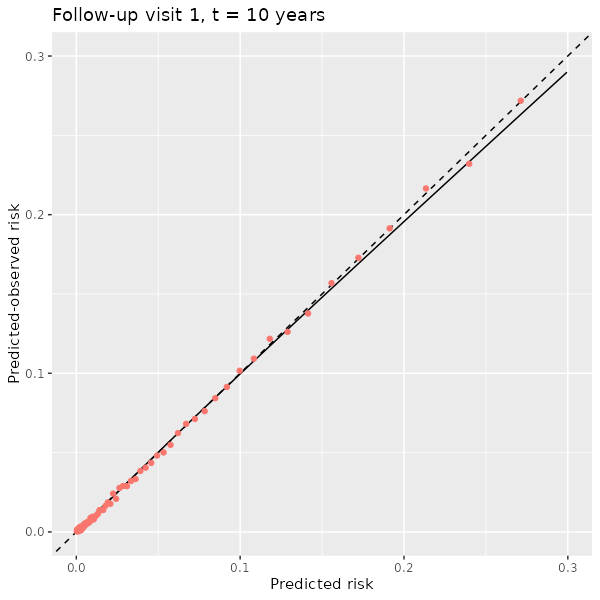

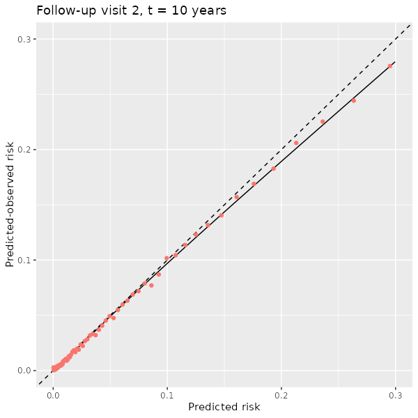

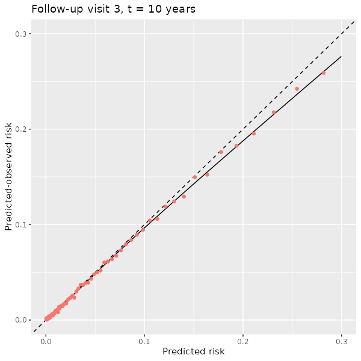

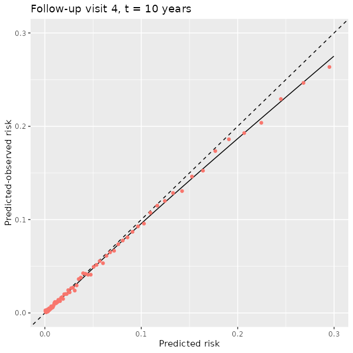

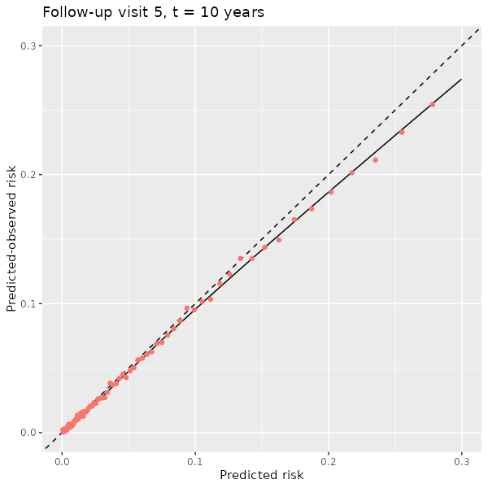

### 5.1.2 Male

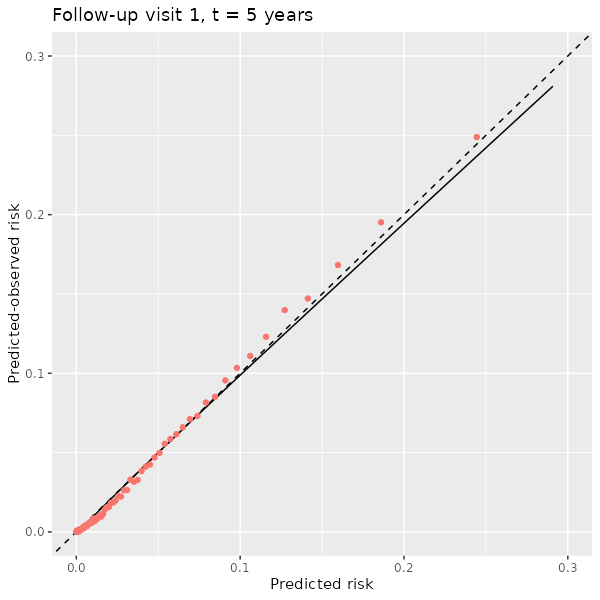

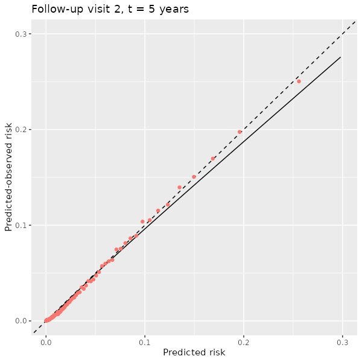

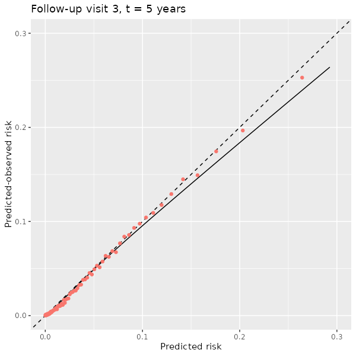

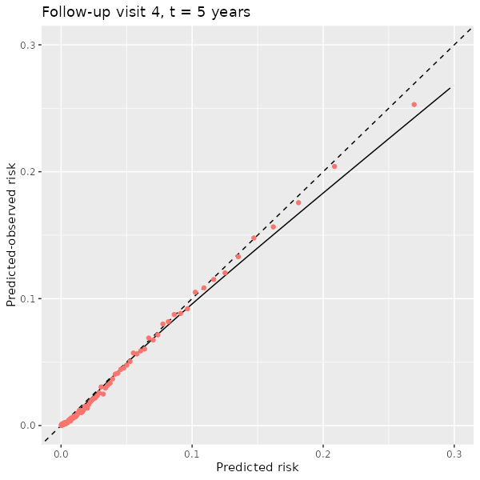

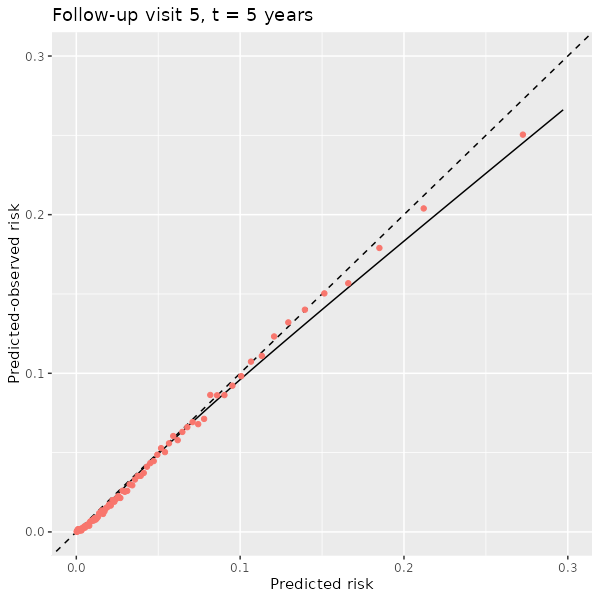

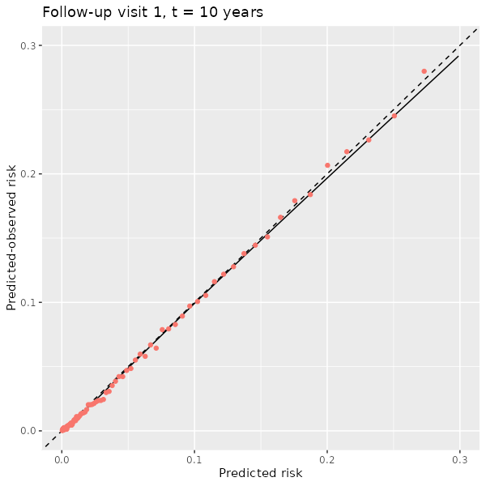

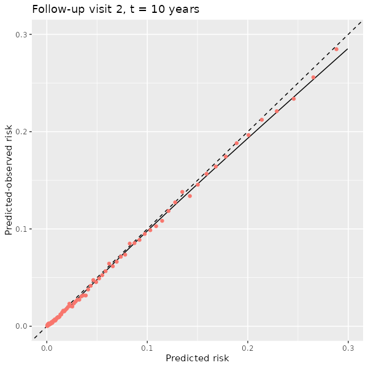

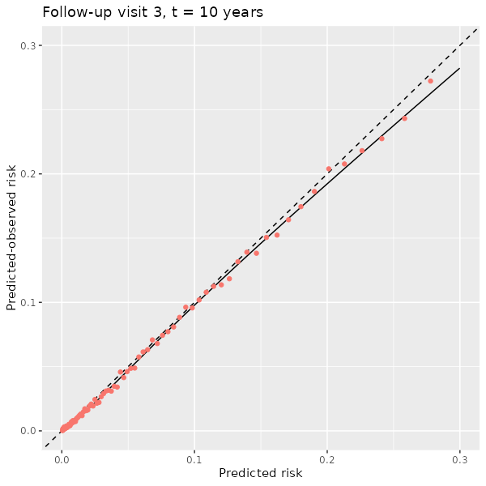

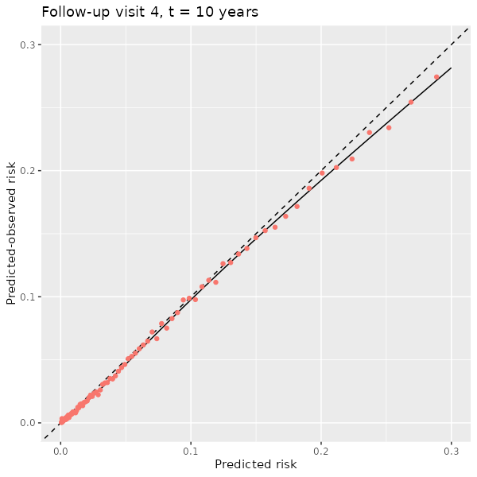

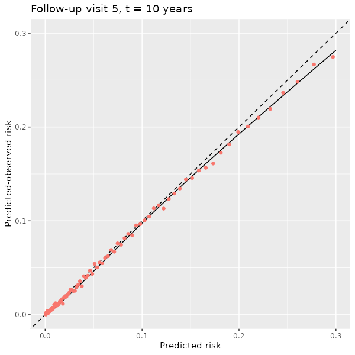

## 5.2 Calibration tables

| gender | t | follow-up visit | N | ICI | E50 | E90 |
| --- | --- | --- | --- | --- | --- | --- |
| female | 5 | 1 | 2455459 | 0.000 | 0.000 | 0.000 |
| female | 5 | 2 | 2058812 | 0.001 | 0.000 | 0.003 |
| female | 5 | 3 | 1757932 | 0.002 | 0.001 | 0.004 |
| female | 5 | 4 | 1532580 | 0.002 | 0.001 | 0.006 |
| female | 5 | 5 | 1351932 | 0.003 | 0.001 | 0.007 |
| female | 10 | 1 | 2455459 | 0.001 | 0.000 | 0.002 |
| female | 10 | 2 | 2058812 | 0.003 | 0.001 | 0.007 |
| female | 10 | 3 | 1757932 | 0.003 | 0.001 | 0.009 |
| female | 10 | 4 | 1532580 | 0.004 | 0.002 | 0.011 |
| female | 10 | 5 | 1351932 | 0.005 | 0.002 | 0.013 |
| male | 5 | 1 | 2425374 | 0.001 | 0.000 | 0.001 |
| male | 5 | 2 | 2077642 | 0.001 | 0.001 | 0.003 |
| male | 5 | 3 | 1793566 | 0.002 | 0.001 | 0.004 |
| male | 5 | 4 | 1562777 | 0.002 | 0.001 | 0.004 |
| male | 5 | 5 | 1374424 | 0.002 | 0.001 | 0.004 |
| male | 10 | 1 | 2425374 | 0.001 | 0.001 | 0.003 |
| male | 10 | 2 | 2077642 | 0.003 | 0.002 | 0.006 |
| male | 10 | 3 | 1793566 | 0.004 | 0.002 | 0.008 |
| male | 10 | 4 | 1562777 | 0.004 | 0.003 | 0.009 |
| male | 10 | 5 | 1374424 | 0.005 | 0.003 | 0.010 |

## 5.3 Discrimination

| gender | t | follow-up visit | N | C_index | index_lower | index_upper |
| --- | --- | --- | --- | --- | --- | --- |
| female | 5 years | 1 | 2455459 | 0.867 | 0.867 | 0.867 |
| female | 5 years | 2 | 2058812 | 0.859 | 0.859 | 0.859 |
| female | 5 years | 3 | 1757932 | 0.853 | 0.853 | 0.853 |
| female | 5 years | 4 | 1532580 | 0.847 | 0.847 | 0.847 |
| female | 5 years | 5 | 1351932 | 0.841 | 0.841 | 0.841 |
| female | 10 years | 1 | 2455459 | 0.867 | 0.867 | 0.867 |
| female | 10 years | 2 | 2058812 | 0.859 | 0.859 | 0.859 |
| female | 10 years | 3 | 1757932 | 0.853 | 0.853 | 0.853 |
| female | 10 years | 4 | 1532580 | 0.847 | 0.847 | 0.847 |
| female | 10 years | 5 | 1351932 | 0.841 | 0.841 | 0.841 |
| male | 5 years | 1 | 2425374 | 0.850 | 0.850 | 0.850 |
| male | 5 years | 2 | 2077642 | 0.842 | 0.842 | 0.842 |
| male | 5 years | 3 | 1793566 | 0.834 | 0.834 | 0.834 |
| male | 5 years | 4 | 1562777 | 0.826 | 0.826 | 0.826 |
| male | 5 years | 5 | 1374424 | 0.818 | 0.818 | 0.818 |
| male | 10 years | 1 | 2425374 | 0.850 | 0.850 | 0.850 |
| male | 10 years | 2 | 2077642 | 0.842 | 0.842 | 0.842 |
| male | 10 years | 3 | 1793566 | 0.834 | 0.834 | 0.834 |
| male | 10 years | 4 | 1562777 | 0.826 | 0.826 | 0.826 |
| male | 10 years | 5 | 1374424 | 0.818 | 0.818 | 0.818 |

# 6 Temporal validation of intervention layer

Follow-up index dates are defined at 1/2/3/4/5 years after baseline. Calibration and discrimination are assessed at 5 and 10 years. We assess interventional changes in each modifiable risk factor sequentially.

In plots and tables, t_fup = number of days after baseline the index date is defined at, t_eval is denoting whether evaluating 5 or 10 year risk predictions, mfr denotes the modifiable risk factor being evaluated.

## 6.1 Calibration plots

### 6.1.1 SBP

#### 6.1.1.1 Female

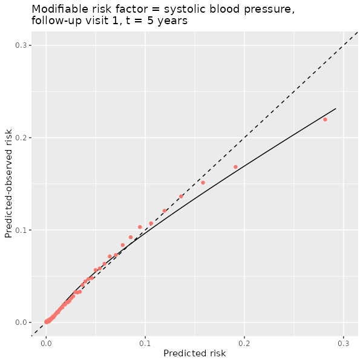

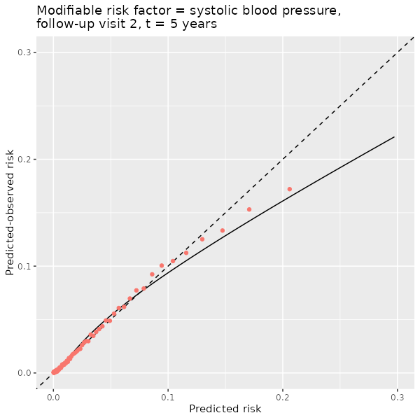

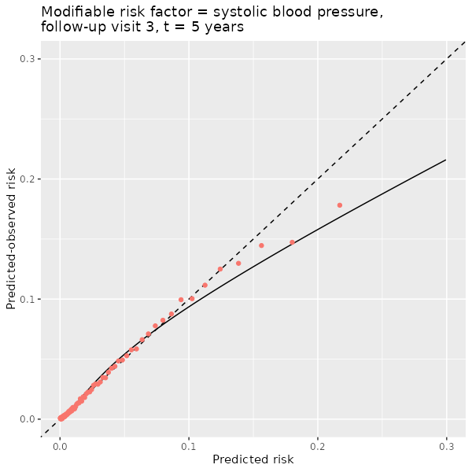

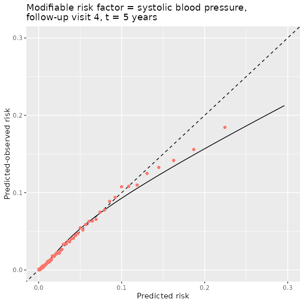

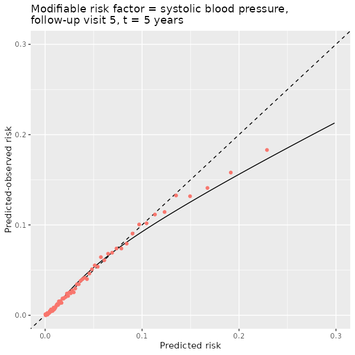

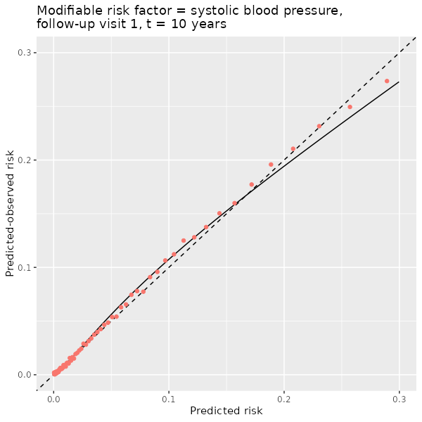

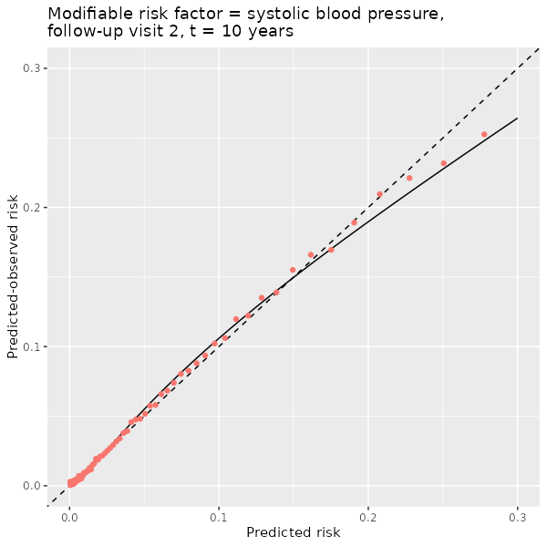

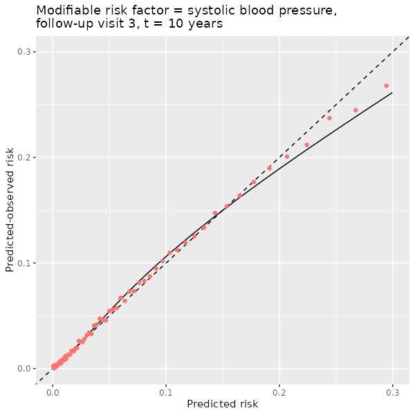

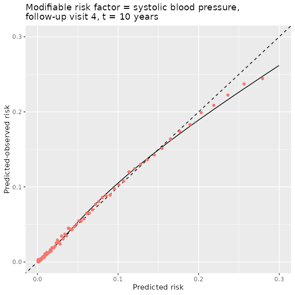

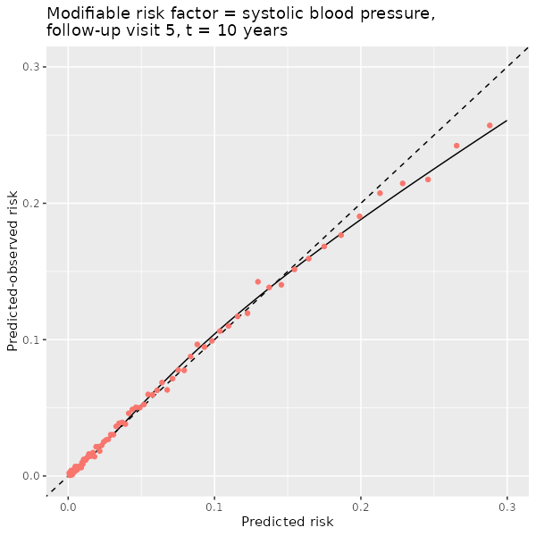

#### 6.1.1.2 Male

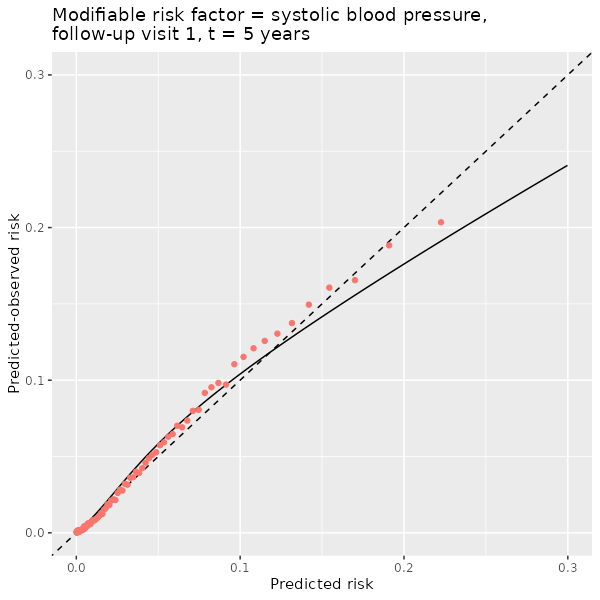

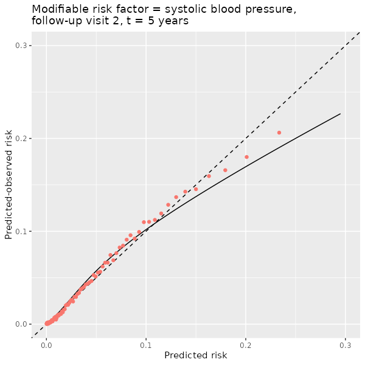

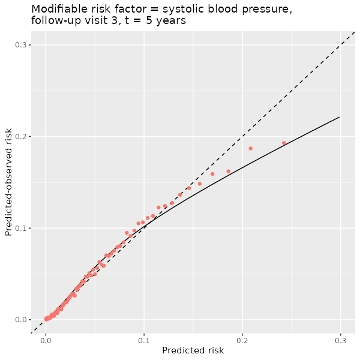

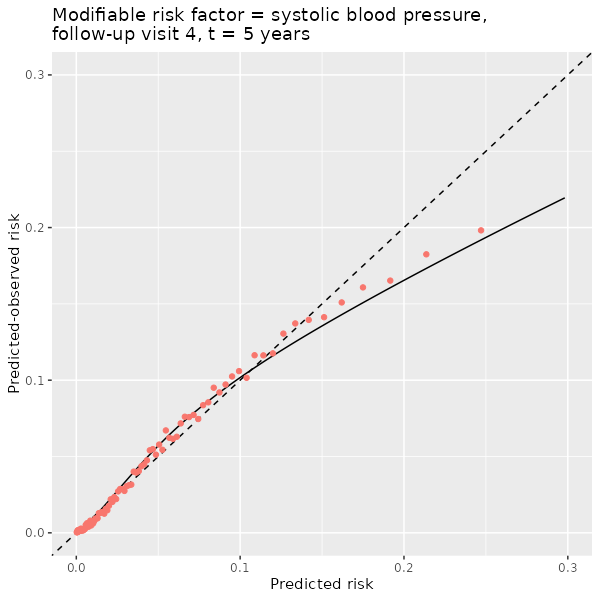

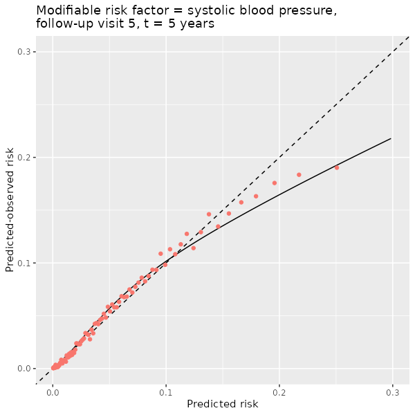

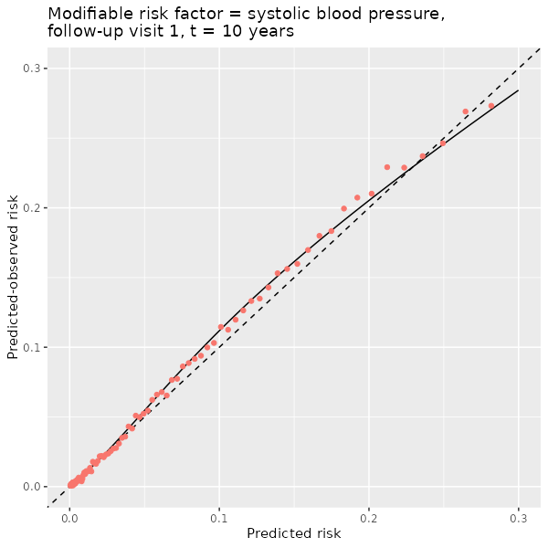

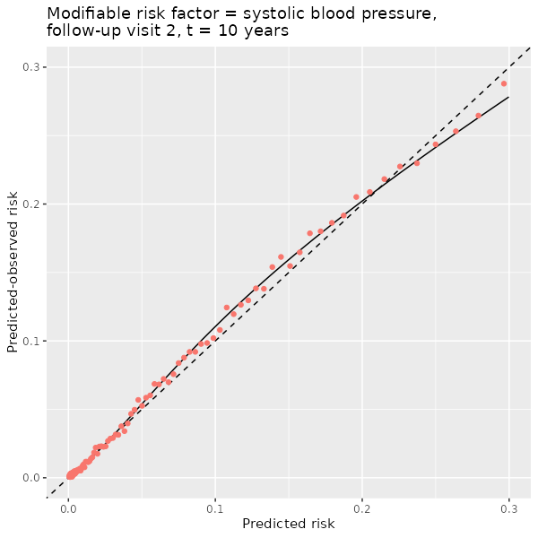

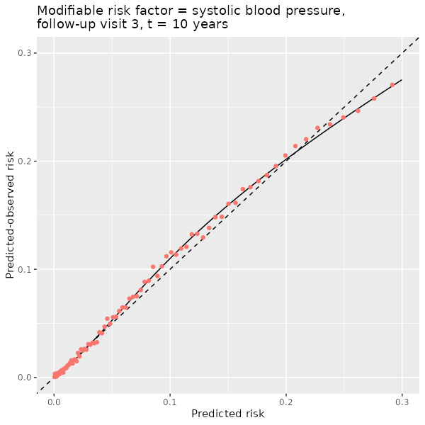

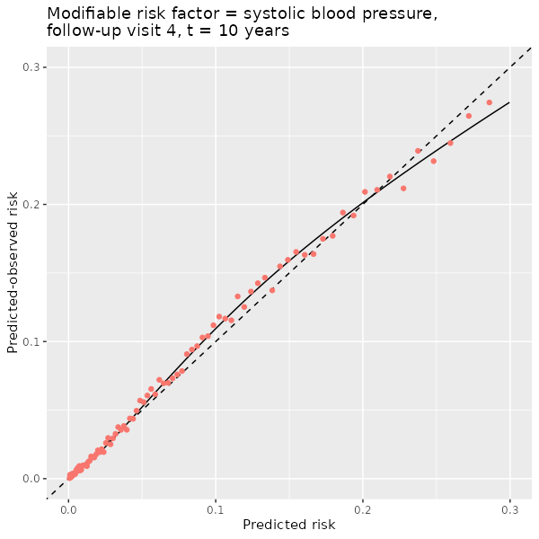

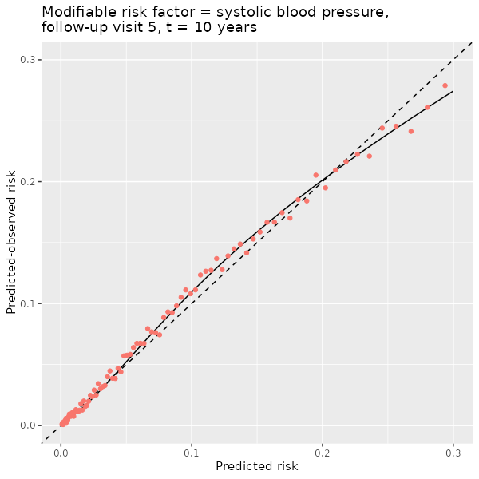